# Tarea-04

## Pruebas visuales y Permutación

#### Pruebas de permutación

1. La tabla de datos *Phillies2009* contiene información de la temporada de baseball 2009 para el equipo de Philadelphia *Phillies*, en este ejercicio queremos comparar los strikes (`StrikeOuts`) entre los juegos en casa y de visitante:
1. Realiza un *lineup* donde cada panel muestre un diagrama de caja y brazos para la variable de interés separando los juegos jugados en casa (home) y los juegos jugados fuera (away). ¿Puedes localizar los datos verdaderos entre los nulos?

```r
setwd("~/Maestría Ciencia de datos/Fundamentos estadísticos/Tarea 04")

library(tidyverse)
library(dplyr)
library(nullabor)
library(patchwork)

N_rep <- 100

phillies <- read_csv("Phillies2009.csv")
glimpse(phillies)
```

```
## Rows: 162
## Columns: 7
## $ Date       <chr> "5-Apr", "7-Apr", "8-Apr", "10-Apr", "11-Apr", "12-Apr",...
## $ Location   <chr> "Home", "Home", "Home", "Away", "Away", "Away", "Away", ...
## $ Outcome    <chr> "Lose", "Lose", "Win", "Lose", "Win", "Win", "Win", "Los...
## $ Hits       <dbl> 4, 6, 11, 7, 15, 13, 10, 5, 14, 8, 9, 13, 8, 2, 8, 9, 12...
## $ Doubles    <dbl> 2, 1, 3, 2, 3, 3, 3, 1, 3, 2, 1, 4, 0, 0, 2, 0, 2, 5, 0,...
## $ HomeRuns   <dbl> 0, 0, 1, 1, 1, 2, 3, 0, 1, 3, 3, 1, 1, 1, 2, 2, 0, 2, 4,...
## $ StrikeOuts <dbl> 6, 3, 6, 3, 6, 4, 7, 3, 5, 7, 5, 8, 4, 4, 12, 8, 7, 7, 5...
```

```r
perms_Loc <- lineup(null_permute('Location'), phillies, n = 12)
```

```
## decrypt("Iw5d XVqV Hz k2AHqH2z 9R")
```

```r
decrypt("Iw5d XVqV Hz k2AHqH2z tt")
```

[output not shown]

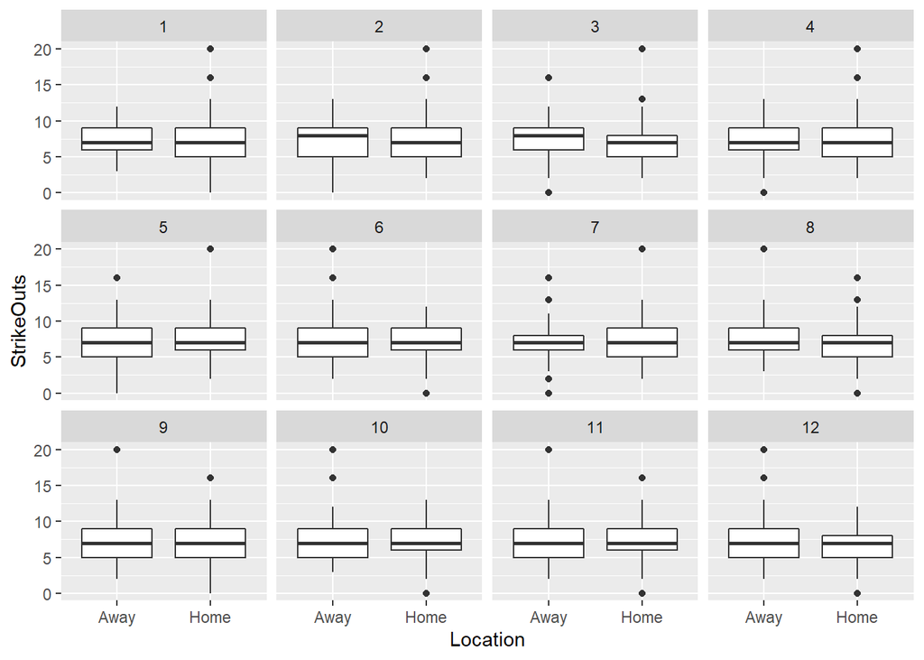

```r
ggplot(perms_Loc, aes(x = Location, y = StrikeOuts)) +
  geom_boxplot() +
  facet_wrap(~.sample)
```

No tenemos evidencia para rechar la hipótesis nula, ya que a simple vista no se puede distinguir

2. Calcula el promedio de strikes por juego en cada grupo (donde grupo se define por Location).

```r
phillies_Loc <- phillies %>%
  select(Location, StrikeOuts)


medias_Loc <- phillies_Loc %>%
  group_by(Location) %>%
  summarise(medias = mean(StrikeOuts), .groups = 'drop')

medias_Loc
```

```
## # A tibble: 2 x 2
##   Location medias
##   <chr>     <dbl>
## 1 Away       7.31
## 2 Home       6.95
```

3. Realiza una prueba de permutación para la diferencia de las medias. Grafica la distribución de referencia y calcula el valor *p* de dos colas.

```r
dif_obs <- phillies_Loc %>%
  group_by(Location) %>%
  summarise(medias = mean(StrikeOuts), .groups = 'drop') %>%
  pivot_wider(names_from = Location, values_from = medias) %>%
  mutate(dif = Away - Home) %>%
  pull(dif)

dif_obs
```

```
## [1] 0.3580247
```

La diferencia de las medias es 0.358, pero al ser una diferencia de medias, consideramos se trata de una prueba de dos colas, esto es ya que restamos “Home” a “Away” se podría considerear la inversa

```r
perms_phillies <- lineup(null_permute('Location'), phillies_Loc, n = 1000)
```

```
## decrypt("Iw5d XVqV Hz k2AHqH2z 9TF")
```

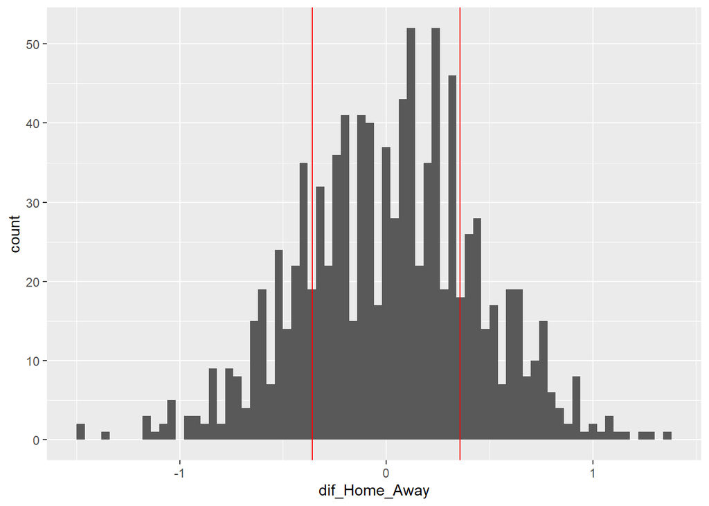

```r
resumen <- perms_phillies %>%
  group_by(Location, .sample) %>%
  summarise(media = mean(StrikeOuts), .groups = 'drop') %>%
  pivot_wider(names_from = Location, values_from = media) %>%
  mutate(dif_Home_Away = Home - Away)

ggplot(resumen, aes(x = dif_Home_Away)) +
  geom_histogram(binwidth = 0.04) +
  geom_vline(xintercept = dif_obs, colour = "red") +
  geom_vline(xintercept = -dif_obs, colour = "red")
```

Al visualizar las 1,000 permutaciones y colocar el dato de la diferencia de las medias podemos observar que no parece ser que sea un valor extremos

```r
dist_perm <- ecdf(resumen$dif_Home_Away)
percentil_obs <- dist_perm(dif_obs)

p_valor <- 2 * min(dist_perm(dif_obs), (1 - dist_perm(dif_obs)))
```

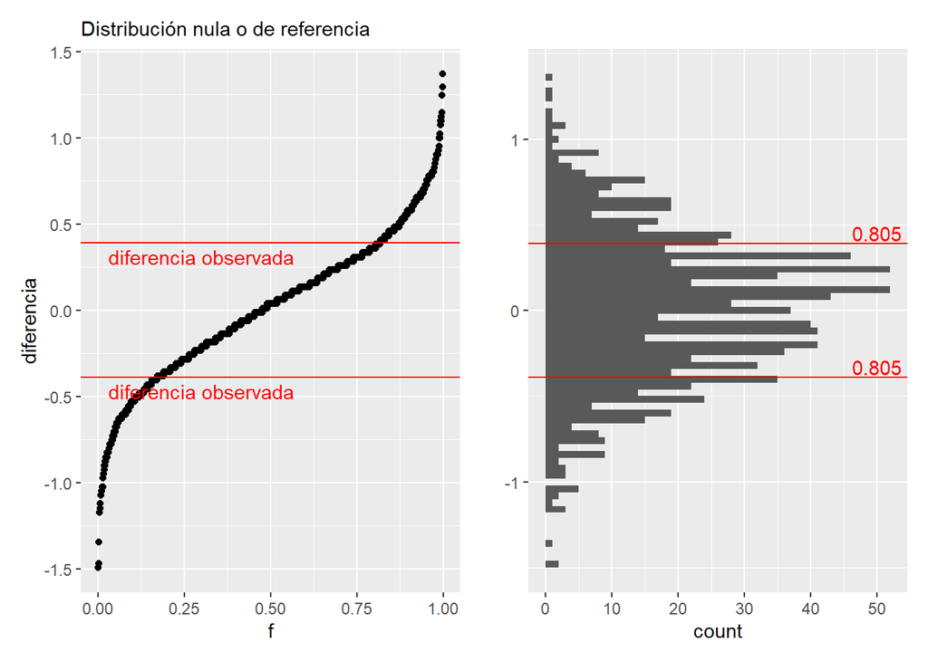

```r
g_1 <- ggplot(resumen, aes(sample = dif_Home_Away)) + geom_qq(distribution = stats::qunif)  +
  xlab("f") + ylab("diferencia") + labs(subtitle = "Distribución nula o de referencia") +
  geom_hline(yintercept = p_valor, colour = "red") +
  geom_hline(yintercept = -p_valor, colour = "red") +
  annotate("text", x = 0.3, y = p_valor - 0.08, label = "diferencia observada", colour = "red") +
  annotate("text", x = 0.3, y = -p_valor - 0.08, label = "diferencia observada", colour = "red")

g_2 <- ggplot(resumen, aes(x = dif_Home_Away)) +
  geom_histogram(binwidth = 0.04) +
  coord_flip() + xlab("") + labs(subtitle = " ") +
  geom_vline(xintercept = p_valor, colour = "red") +
  geom_vline(xintercept = -p_valor, colour = "red") +
  annotate("text", x = p_valor, y = 50, label = percentil_obs,vjust = -0.2, colour = "red") +
  annotate("text", x = -p_valor, y = 50, label = percentil_obs,vjust = -0.2, colour = "red")
g_1 + g_2
```

Y vemos que es un valor no extremo en la distribución de referencia que vemos arriba: esta muestra no aporta evidencia para rechazar la hipotesis nula

## Pruebas pareadas

En este ejemplo buscamos comparar la diferencia entre dos medicinas para dormir. - ID es el identificador de paciente, y medicina_1 y medicina_2 son las horas extras de sueño vs. no usar medicina.  
- Examina los datos.

```r
dormir <- sleep %>%
  pivot_wider(names_from = group,
              names_prefix = "medicina_",
              values_from = extra)

dormir
```

```
## # A tibble: 10 x 3
##    ID    medicina_1 medicina_2
##    <fct>      <dbl>      <dbl>
##  1 1            0.7        1.9
##  2 2           -1.6        0.8
##  3 3           -0.2        1.1
##  4 4           -1.2        0.1
##  5 5           -0.1       -0.1
##  6 6            3.4        4.4
##  7 7            3.7        5.5
##  8 8            0.8        1.6
##  9 9            0          4.6
## 10 10           2          3.4
```

La pregunta de interés es si una medicina es mejor que otra para prolongar el sueño. Nótese que en este caso, no tenemos grupos, sino mediciones repetidas.

- Escribe la hipótesis nula.

$$H_0: \mu_1 = \mu_2$$

Donde la hipótesis nula nos dice que las medias de ambas medicinas tienen el mismo efecto, esto ya que si rechazamos la hipótesis nula implicaría que una de las dos es mayor a la otra y por ende diferente.

- Nuestra estadśtica de interés es media de las diferencias entre las medicinas.

Calcula la diferencia observada.

```r
summary(dormir)
```

```
##        ID      medicina_1       medicina_2
##  1      :1   Min.   :-1.600   Min.   :-0.100
##  2      :1   1st Qu.:-0.175   1st Qu.: 0.875
##  3      :1   Median : 0.350   Median : 1.750
##  4      :1   Mean   : 0.750   Mean   : 2.330
##  5      :1   3rd Qu.: 1.700   3rd Qu.: 4.150
##  6      :1   Max.   : 3.700   Max.   : 5.500
##  (Other):4
```

```r
dif_obs_dormir <- mean(dormir$medicina_2) - mean(dormir$medicina_1)
```

- Hay variación entre los pacientes. ¿Tenemos evidencia para rechazar que son iguales? ¿Cómo hacemos nuestra distribución de referencia?

```r
perms_dormir <- lineup(null_permute('group'), sleep, n = 1000)
```

```
## decrypt("Iw5d XVqV Hz k2AHqH2z m9s")
```

```r
glimpse(perms_dormir)
```

```
## Rows: 20,000
## Columns: 4
## $ extra   <dbl> 0.7, -1.6, -0.2, -1.2, -0.1, 3.4, 3.7, 0.8, 0.0, 2.0, 1.9, ...
## $ group   <fct> 1, 1, 2, 2, 2, 2, 2, 1, 1, 2, 1, 1, 2, 2, 1, 1, 1, 1, 2, 2,...
## $ ID      <fct> 1, 2, 3, 4, 5, 6, 7, 8, 9, 10, 1, 2, 3, 4, 5, 6, 7, 8, 9, 1...
## $ .sample <dbl> 1, 1, 1, 1, 1, 1, 1, 1, 1, 1, 1, 1, 1, 1, 1, 1, 1, 1, 1, 1,...
```

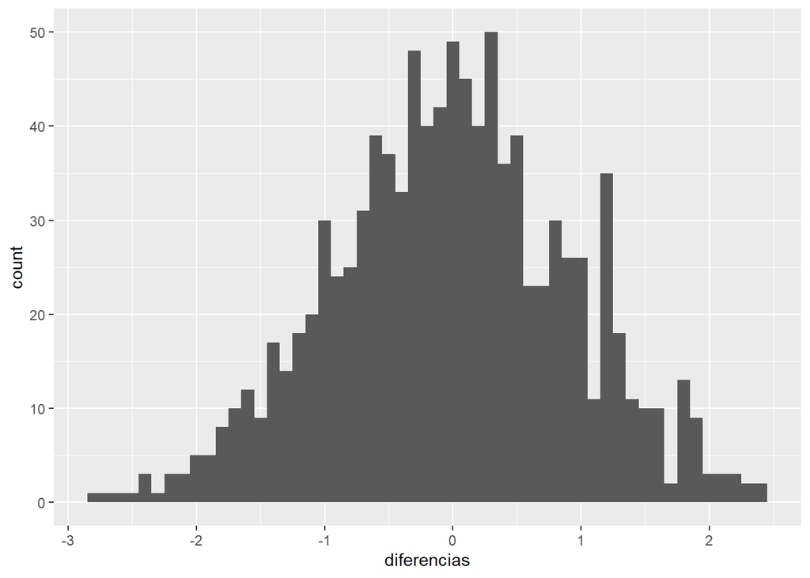

```r
resumen <-  perms_dormir %>%
  group_by(.sample, group) %>%
  summarise(medias = mean(extra), .groups = 'drop') %>%
  pivot_wider(names_from = group, names_prefix = 'medicina_', values_from = medias) %>%
  mutate(diferencias = medicina_2 - medicina_1)

ggplot(resumen, aes(x = diferencias)) +
  geom_histogram(binwidth = 0.1)
```

Podemos ver que la diferencia de las medias parece ser un dato extremo pero no podemos decir que no podemos rechazar la hipótesis nula de la diferencia de los medicamentos

- Haz una gráfica de la distribución de referencia y grafica encima el valor observado en los datos originales.

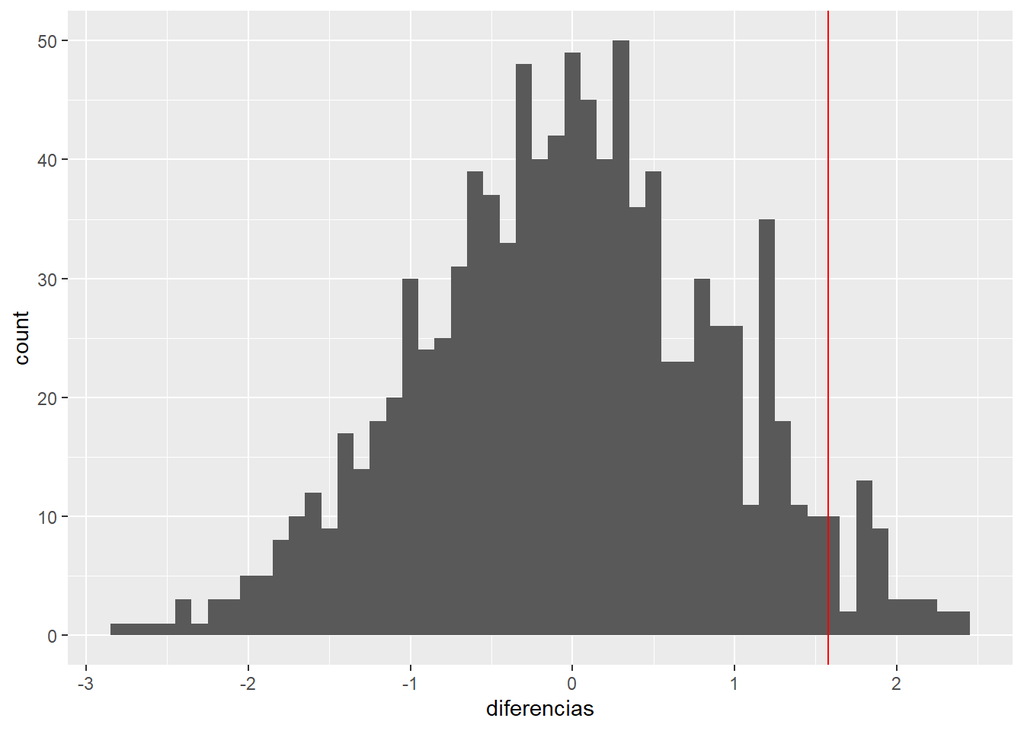

```r
ggplot(resumen, aes(x = diferencias)) +
  geom_histogram(binwidth = 0.1) +
  geom_vline(xintercept = dif_obs_dormir, color = 'red')
```

- Calcula el valor p (justifica porque a una o dos colas).

```r
dist_perm <- ecdf(resumen$diferencias)
percentil_obs <- dist_perm(dif_obs_dormir)

p_valor <- 2 * min(dist_perm(dif_obs_dormir), (1 - dist_perm(dif_obs_dormir)))

p_valor
```

```
## [1] 0.08
```

## Valores-*p*

Cuando usamos simulación para pruebas de permutación, el valor-*p* de una cola se puede calcular como

$$\hat{P}=(X+1)/(N+1)$$

donde $X$ es el número de estadísticas de prueba remuestreadas que son al menos tan extremas como la observada. Supongamos que el verdadero valor *p* (si pudiéramos hacer todas las permutaciones de manera exhaustiva) es $p$

- ¿Cuál es la varianza de $\hat{P}$?

Por fórmula tenemos que:
$$Var(\hat{P}) = \frac{\hat{P}(1-\hat{P})}{N}$$

```r
varianza_p = p_valor * (1 - p_valor) /nrow(dormir)

varianza_p
```

```
## [1] 0.00736
```

- ¿Cuál es la varianza de $\hat{P_2}$ para la prueba de dos lados? (suponiendo que $p$ no es cercano a $0.5$, donde $p$ es el verdadero valor *p* para la prueba de una cola).

Para la prueba de dos colas aplicando la formula tenemos que

$$Var(\hat{P}_2) = var(2\hat{P})$$
$$= 4Var(\hat{P})$$
$$= 4Var(\frac{X+1}{N+1})$$
$$= \frac{4}{(N+1)^2}Var(X)$$
$$= \frac{4N\hat{P}(1-\hat{P})}{(N+1)^2}$$
Aplicando esta fórmula tenemos que:

```r
N <- nrow(dormir)
varianza_p_2 = 4 * N * p_valor * (1 - p_valor) /(N+1)^2

varianza_p_2
```

```
## [1] 0.02433058
```